# Prepayment Model Based on FNMA Loan Performance Data

**Chengjia Dong, Junru Wang, Yifan Meng**  
**IE598: Structured Credit**

This file will contain our Python Code and brief summary of work. More detailed analysis would be put in PDF Report in consideration of simplicity.

## 1. Data Used

We utilized several datasets to build our analysis and model:

- **Fannie Mae House Price Index (HPI):** Used to understand the fluctuations in the real estate market.
- **FNMA Loan Performance Data (Q1 2015 & Q1 2019):** This detailed dataset was large and had to be read in chunks, then concatenated.
- **Freddie Mac Mortgage Loan Rate Data (weekly):** We converted the weekly rates into monthly values and merged them with the loan performance data to calculate scheduled interest payments and the prepayment rate (Single Monthly Mortality, SMM).
- **Macroeconomic Data:** Incorporated to provide a broader economic context for our analysis.

## 4. Lock-in Effect

In 2022, the Federal Reserve realized the inflation problem and began raising interest rates. This led to an increase in mortgage rates, locking borrowers into higher rates. We used regression models to group estimate model parameters and visualized the curves for different groups together.

## 5. Curtailment

Curtailment refers to partial prepayments, where borrowers make additional principal payments beyond the scheduled ones. We calculated this based on the formulas provided by our instructor and made appropriate adjustments to ensure accuracy.

```python
# Data Process
import pandas as pd
selected_cols = [9, 11, 49, 1, 2, 7, 8, 12, 13, 14, 15, 16, 17, 19, 22, 23, 26, 29, 30]
chunksize = 10000

# 2015Q1
chunks = pd.read_csv('./2015Q1.csv', sep='|', header=None, chunksize=chunksize,
usecols = selected_cols)
df = pd.concat(chunks, ignore_index=True)

# 2019Q1
chunks = pd.read_csv('./2019Q1.csv', sep='|', header=None, chunksize=chunksize,
usecols = selected_cols)
df2 = pd.concat(chunks, ignore_index=True)

# sort and rename data index
col_names = ['Original UPB',
                    'Current Actual UPB',
                    'Unscheduled Principal Current',
                    'Loan Identifier',           # 2
                    'Monthly Reporting Period',  # 3
                    'Original Interest Rate',    # 8
                    'Current Interest Rate',      # 9
                    'Original Loan Term',        # 13
                    'Origination Date',          # 14
                    'First Payment Date',        # 15
                    'Loan Age',                  # 16
                    'Remaining Months to Legal Maturity', # 17
                    'Remaining Months To Maturity', # 18
                    'Original LTV',             # 20
                    'Debt-To-Income (DTI)',     # 23
                    'FICO at Origination',      # 24
                    'Loan Purpose',              # 27
                    'Occupancy Status',          # 30
                    'Property State'             # 31
]

sorted_pairs = sorted(zip(selected_cols, col_names))
col_sorted, col_names_sorted = zip(*sorted_pairs)
df.columns = col_names_sorted
df2.columns = col_names_sorted

df.to_parquet('2015Q1.parquet', engine='pyarrow')
df2.to_parquet('2019Q1.parquet', engine='pyarrow')
```

# Rate Refi (S Curve)

S curve by following characteristics:  
▪ X-axis incentive buckets:  
o <-100bps, -100 to -50bps, -50 to 0bps, 0 to 50bps, 50 to 100 bps, 100 to 150 bps, 150+ bps  
▪ Calculate and plot the SMM for each criteria (bucket by reasonable sample sizes):  
**o FICO, Loan Size(original loan balance), Occupancy type, Loan purpose, DTI, Geography (NY/FL/TX, other)**  
o Provide summary statistics and reasoning  
o Does the result make sense?

**Calculate Monthly Interest Rate:** $$ \text{Monthly Interest Rate} = \frac{\text{Original Interest Rate}}{12 \times 100} $$

**Calculate the monthly interest portion:** $$ \text{Interest Payment} = P \times r $$

**Calculate the monthly principal portion:** $$ \text{Scheduled Principal} = A - \text{Interest Payment} $$

### 1.Data preparation

Input: 2015Q1.parquet, 2019Q1.parquet, Data.xls  
Output: 2015Q1_2.parquet, 2019Q1_2.parquet

```python
# mortgage data
import pandas as pd
import dask.dataframe as dd


def calculate_SMM(data):
    # ignore the first 12 months
    data['Month'] = data['Monthly Reporting Period'] // 10000
    data['Year'] = data['Monthly Reporting Period'] % 10000
    data['Monthly_Rate'] = data['Original Interest Rate'] / 100 / 12

    data['Scheduled Payment'] = data['Original UPB'] * (data['Monthly_Rate'] * (1 + data['Monthly_Rate'])**
                                          data['Original Loan Term']) / ((1 + data['Monthly_Rate'])**
                                                                         data['Original Loan Term'] - 1)

    data['Interest_Payment'] = data['Current Actual UPB'] * data['Monthly_Rate']

    data['Scheduled Principal Payment'] = data['Scheduled Payment'] - data['Interest_Payment']

    data['Total Principal Current'] = data.groupby('Loan Identifier')['Current Actual UPB'].transform(lambda x: x - x.shift(-1))

    data['Unscheduled Payment'] = (data['Total Principal Current'] - data['Scheduled Principal Payment']).clip(lower=0)

    data['SMM'] = data['Unscheduled Payment'] / (data['Current Actual UPB']+data['Total Principal Current']-data['Scheduled Principal Payment'])
    #data['SMM'] = data['SMM'].clip(lower=0, upper=1)

    return data
```

```python
Q1_2015 = dd.read_parquet('./2015Q1.parquet')
Q1_2015 = calculate_SMM(Q1_2015).compute()
Q1_2015.to_parquet('2015Q1_2.parquet', engine='pyarrow')
```

```python
Q1_2019 = dd.read_parquet('./2019Q1.parquet')
Q1_2019 = calculate_SMM(Q1_2019).compute()
Q1_2019.to_parquet('2019Q1_2.parquet', engine='pyarrow')
```

### 2. Loading Data

Directly run from here with processed data

```python
import pandas as pd

# macroecon data
rate = pd.read_excel('Data.xls',sheet_name = 'Interest Rate')
unemployment = pd.read_excel('Data.xls',sheet_name = 'Unemployment Rate')
income = pd.read_excel('Data.xls',sheet_name = 'Income')

# weekly mortgage performance
header_rows = pd.read_excel('Data.xls', header=None, nrows=3, sheet_name='Mortagage Summary')
new_header = header_rows.astype(str).agg(' '.join, axis=0)

weeklyloan = pd.read_excel('Data.xls', header=None, skiprows=3, sheet_name='Mortagage Summary')
weeklyloan.columns = new_header
weeklyloan.columns = ['Date'] + weeklyloan.columns[1:].tolist()
weeklyloan['Date'] = pd.to_datetime(weeklyloan['Date'], errors='coerce')
weeklyloan['Month'] = weeklyloan['Date'].dt.month
weeklyloan['Year'] = weeklyloan['Date'].dt.year

monthly_rate =weeklyloan[['Year','Month','U.S. 30 yr FRM']].groupby(['Year', 'Month'])['U.S. 30 yr FRM'].mean().reset_index()
```

### 3.Draw S-curve

```python
import seaborn as sns
import matplotlib.pyplot as plt

def prepare_data(data):
    data_S_curve = data[['Year', 'Month', 'Original Interest Rate','SMM']]
    data_S_curve = data.merge(monthly_rate, on=['Year', 'Month'], how='left')
    data_S_curve['Refi Incentive'] = (data_S_curve['Original Interest Rate']-data_S_curve['U.S. 30 yr FRM']).shift(2) #lag for 2

    return data_S_curve


def draw_SCurve(data, bucket,label,b):
    bucket_group = bucket+' Group'

    if pd.api.types.is_numeric_dtype(data[bucket]):
        data[bucket_group] = pd.cut(data[bucket], bins=b, labels=label)
    else:
        data[bucket_group] = data[bucket]

    data['Incentive Group'] = pd.cut(data['Refi Incentive'],
                                      bins= [-float('inf'), -1.0, -0.5, 0.0, 0.5, 1.0, 1.5, float('inf')],
                                      labels = ['<-100 bps', '-100 to -50 bps', '-50 to 0 bps', '0 to 50 bps', '50 to 100 bps', '100 to 150 bps', '>150 bps'])

    avg_smm = data.groupby([bucket_group, 'Incentive Group'], observed=True)['SMM'].mean().reset_index()

    plt.figure(figsize=(12, 8))
    sns.lineplot(data=avg_smm, x='Incentive Group', y='SMM', hue=bucket_group, marker='o')


    plt.title(bucket)
    plt.xlabel('Incentive')
    plt.ylabel('Average SMM')
    plt.legend()
    plt.grid()
    plt.xticks(rotation=45)  # 旋转 X 轴标签以便更清晰
    plt.show()
```

```python
buckets = [
    'FICO at Origination',  # FICO
    'Original UPB',         # 原始贷款余额
    'Occupancy Status',     # 占用类型
    'Loan Purpose',         # 贷款目的
    'Debt-To-Income (DTI)', # DTI
    'Property State'        # 地理位置
]

bin_dict = {
    'FICO at Origination': [0, 700, 760, float('inf')],
    'Original UPB': [100000, 150000, 200000, 300000, 400000, 500000, float('inf')],
    'Occupancy Status': ['P','S','I','U'],
    'Loan Purpose': ['C', 'R', 'P', 'U'],
    'Debt-To-Income (DTI)': [0,20,30,40,52],
    'Property State': ['NY','FL','TX', 'Other']
}

label_dict = {
    'FICO at Origination': ['FICO700-', 'FICO700-760', 'FICO760+'],
    'Original UPB': ['<100k', '100k-200k', '200k-300k', '300k-400k', '400k-500k', '>500k'],
    'Occupancy Status': ['Principal', 'Second', 'Investor','Unknown'],
    'Loan Purpose': ['Cash-Out', 'Refinance', 'Purchase','Unknown'],
    'Debt-To-Income (DTI)': ['<20','20~30','30~40','>40'],
    'Property State': ['NY','FL','TX', 'Other']
}
```

```python
import pandas as pd
import numpy as np
Q1_2015 =  pd.read_parquet('./2015Q1_2.parquet')
Q1_2019 = pd.read_parquet('./2019Q1_2.parquet')
```

```python
Q1_2015['Property State'] = np.where(Q1_2015['Property State'].isin(['NY', 'FL', 'TX']),
                                     Q1_2015['Property State'],
                                     'Other')
Q1_2019['Property State'] = np.where(Q1_2019['Property State'].isin(['NY', 'FL', 'TX']),
                                     Q1_2019['Property State'],
                                     'Other')
Q1_2015_S_curve = prepare_data(Q1_2015)
Q1_2019_S_curve = prepare_data(Q1_2019)
```

```
FICO at Origination
```

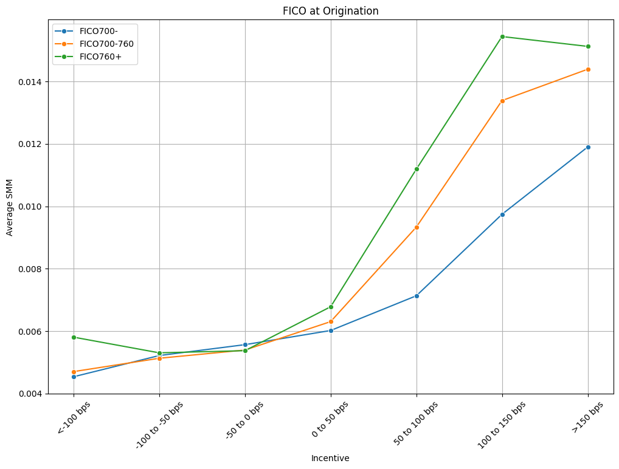

```
Original UPB
```

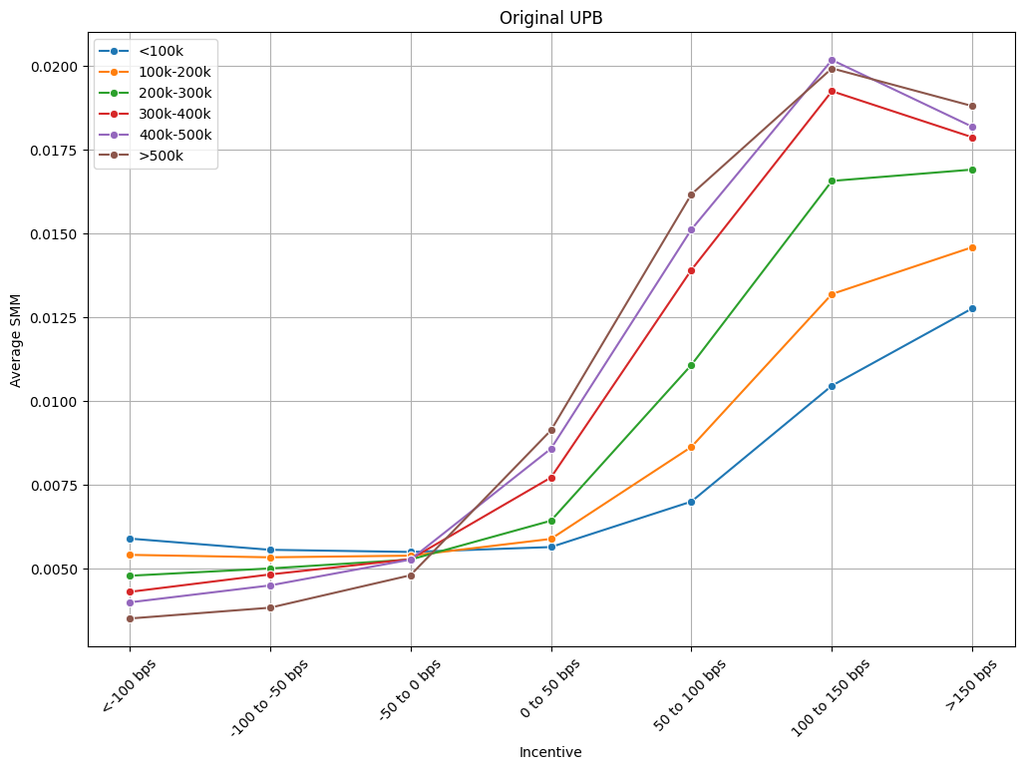

```
Occupancy Status
```

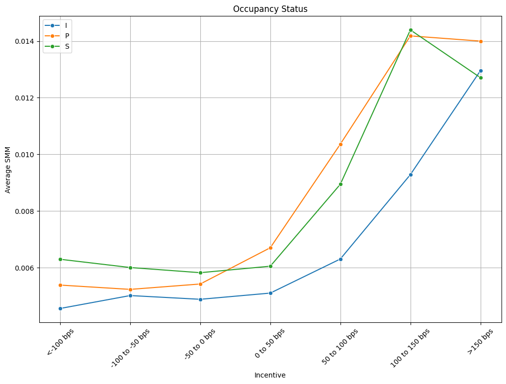

```
Loan Purpose
```

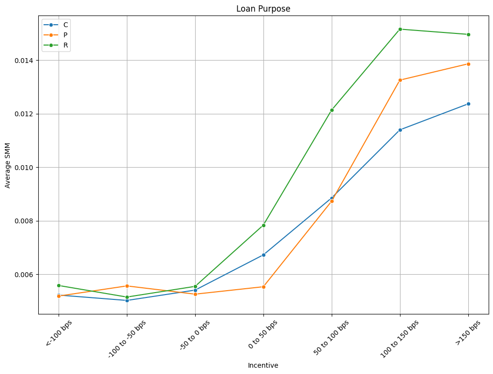

```
Debt-To-Income (DTI)
```

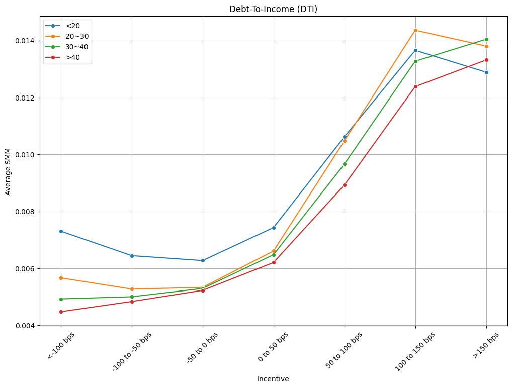

```
Property State
```

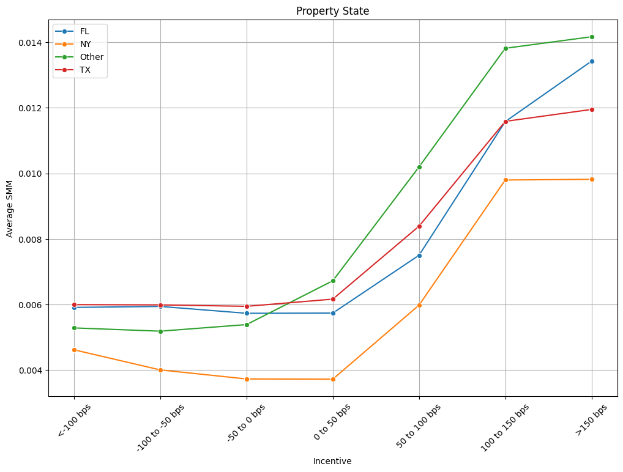

```python
for bucket in buckets:
    print(bucket)
    Q1_2015_S_curve[bucket] = Q1_2015[bucket]
    draw_SCurve(Q1_2015_S_curve, bucket, label_dict[bucket], bin_dict[bucket])
```

```
FICO at Origination
```

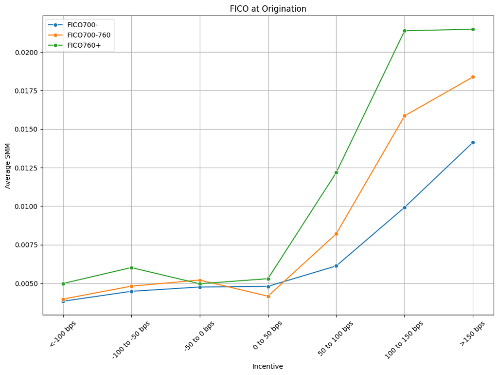

```
Original UPB
```

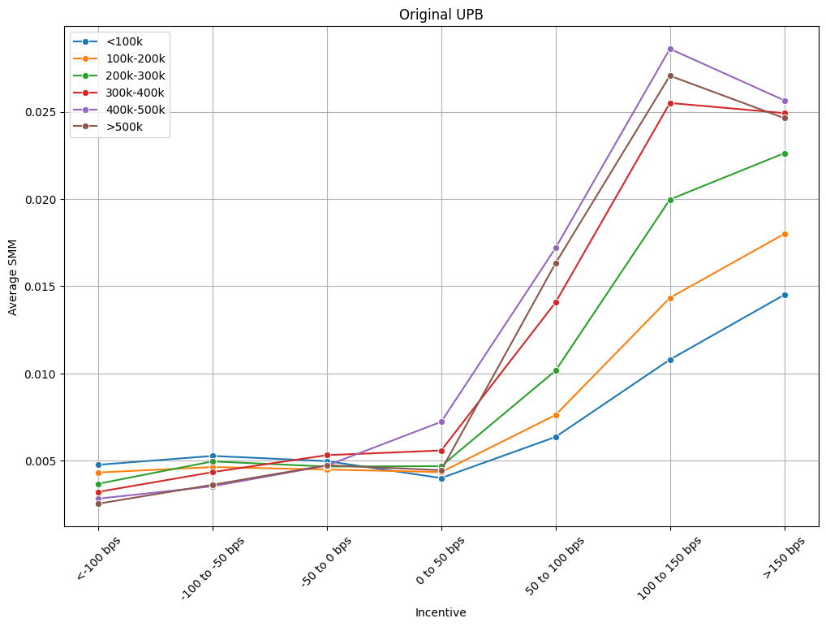

```
Occupancy Status
```

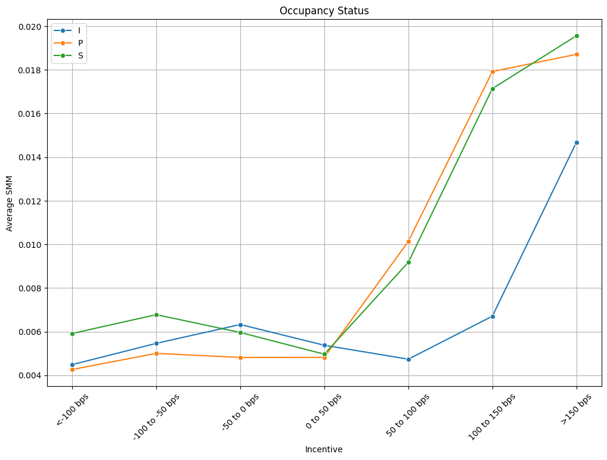

```
Loan Purpose
```

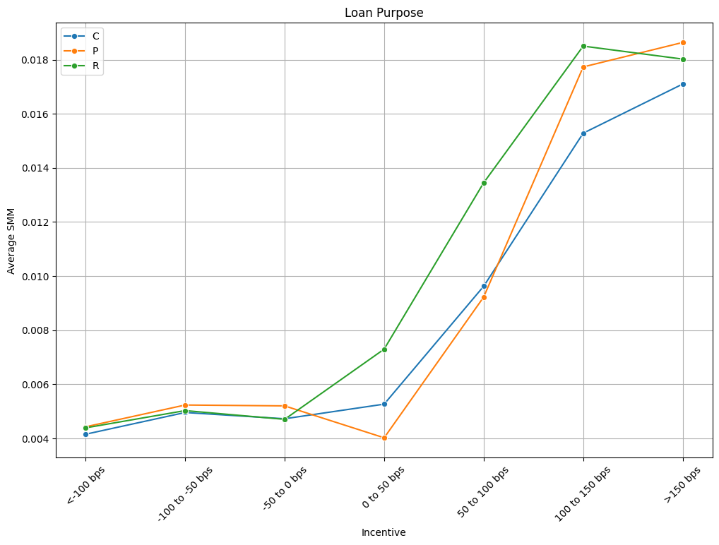

```
Debt-To-Income (DTI)
```

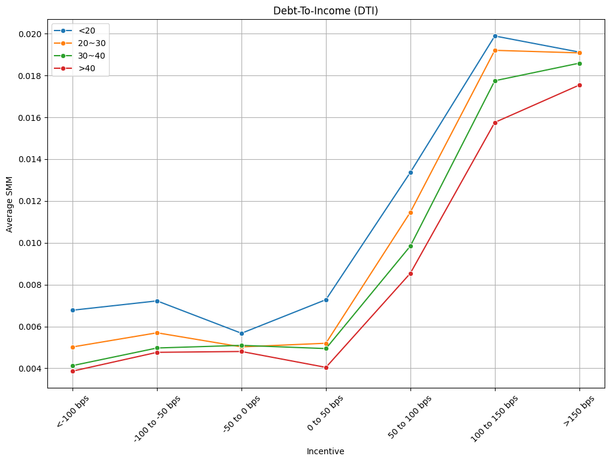

```
Property State
```

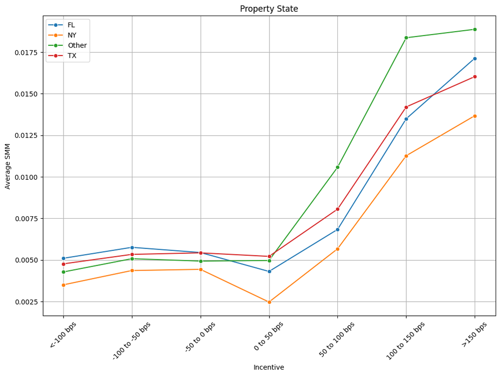

```python
for bucket in buckets:
    print(bucket)
    Q1_2019_S_curve[bucket] = Q1_2019[bucket]
    draw_SCurve(Q1_2019_S_curve, bucket, label_dict[bucket], bin_dict[bucket])
```

# Turn Over

❑ There are several data sources, the Federal Reserve of Saint Loius’s FRED database or Bloomberg  
❑ For the sake of simplicity, one can assume ~6% CPR or 0.51% SMM  
❑ Create an upward sloping ramp to 6CPR by month 30and flat for the remainder  
❑ Adjust each month’s ramp based on month in year based on following table

## (1)Seasonality

```python
monthly_ramp_example = pd.DataFrame({
    "Month": ["Jan", "Feb", "Mar", "Apr", "May", "Jun", "July", "Aug", "Sept", "Oct", "Nov", "Dec"],
    "Seasonality": [0.87, 0.86, 0.87, 0.93, 1.00, 1.08, 1.13, 1.15, 1.12, 1.07, 0.99, 0.91]
})
monthly_ramp_example.set_index("Month", inplace=True)
print(monthly_ramp_example)
```

```
       Seasonality
Month
Jan           0.87
Feb           0.86
Mar           0.87
Apr           0.93
May           1.00
Jun           1.08
July          1.13
Aug           1.15
Sept          1.12
Oct           1.07
Nov           0.99
Dec           0.91
```

```
No artists with labels found to put in legend.  Note that artists whose label start with an underscore are ignored when legend() is called with no argument.
```

```
      Month  Adjusted CPR
0  Jan 2015      0.000000
1  Feb 2015      0.001779
2  Mar 2015      0.003600
3  Apr 2015      0.005772
4  May 2015      0.008276
```

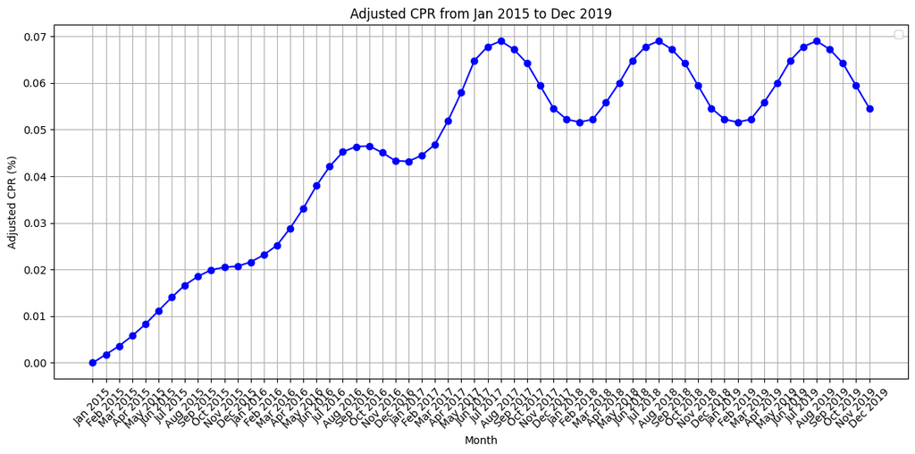

```python
target_cpr = 6.0
months = np.arange(1, 61)

seasonality_series = np.tile(monthly_ramp_example['Seasonality'].values, 5)

ramp = np.linspace(0, target_cpr, 30)
flat_ramp = np.full(30, target_cpr)

full_ramp = np.concatenate((ramp, flat_ramp))

adjusted_ramp = full_ramp * (seasonality_series / 100)

start_date = pd.to_datetime("2015-01-01")
month_names = [start_date + pd.DateOffset(months=i) for i in range(60)]
month_names = [d.strftime("%b %Y") for d in month_names]

result = pd.DataFrame({
    "Month": month_names,
    "Adjusted CPR": adjusted_ramp
})

print(result.head())

plt.figure(figsize=(12, 6))
plt.plot(result['Month'], result['Adjusted CPR'], marker='o', linestyle='-', color='blue')
plt.title('Adjusted CPR from Jan 2015 to Dec 2019')
plt.xlabel('Month')
plt.ylabel('Adjusted CPR (%)')
plt.xticks(rotation=45)
plt.grid()
plt.tight_layout()
plt.legend()
plt.show()
```

## (2)Lock-in effect

```python
import pandas as pd
import numpy as np
import matplotlib.pyplot as plt
from scipy.optimize import curve_fit
from sklearn.metrics import r2_score

# Logistic 函数模型定义
def logistic_func(x, L, k, t0=540):
    return L - L / (1+np.exp(k * (x - t0)))

# 均方误差函数
def cal_mse(y_true, y_pred):
    y_true = np.array(y_true)
    y_pred = np.array(y_pred)
    squared_diff = (y_true - y_pred) ** 2
    mse = np.mean(squared_diff)
    return mse

# 修改后的 lock_in_effect 函数，返回每个 incentive_group 的回归参数
def lock_in_effect(data):
    data['Origination Date'] = pd.to_datetime(data['Origination Date'])

    # 计算 Loan Age
    data['Loan Age'] = (data['Year'] - data['Origination Date'].dt.year) * 12 + \
                    (data['Month'] - data['Origination Date'].dt.month)

    # Refi Incentive 分组
    data['Incentive Group'] = pd.cut(data['Refi Incentive'],
                                      bins= [-float('inf'), -0.6, -0.5, -0.4, -0.3, -0.2, -0.1, 0],
                                      labels = ['-60 bps', '-50 bps', '-40 bps', '-30 bps', '-20 bps', '-10 bps', 'base bps'])
    #data['Incentive Group'] = pd.cut(data['Refi Incentive'],
    #                                 bins= [-float('inf'), -0.3, -0.25, -0.2, -0.15, -0.1, -0.05, 0],
    #                                 labels = ['-60 bps', '-50 bps', '-40 bps', '-30 bps', '-20 bps', '-10 bps', 'base bps'])

    reg_data = data.groupby(['Loan Age', 'Incentive Group'],observed=True)['SMM'].mean().reset_index()
    reg_data = reg_data.replace([np.inf, -np.inf], np.nan).dropna(subset=['Loan Age', 'SMM'])

    # 保存参数的列表
    param_list = []

    # 对每个 Incentive Group 进行 Logistic 回归
    for incentive_group in reg_data['Incentive Group'].unique():
        group_data = reg_data[reg_data['Incentive Group'] == incentive_group]
        X = group_data['Loan Age'].values
        y = group_data['SMM'].values

        # 初始猜测参数 L, k, t0
        initial_params = [0.1, 0.1, 800]

        # 拟合 Logistic 函数
        popt, _ = curve_fit(logistic_func, X, y, p0=initial_params, maxfev=10000)
        L, k, t0 = popt

        # 保存回归参数和 incentive_group
        param_list.append((L, k, t0, incentive_group))

        # 输出回归参数
        print(f'Incentive Group: {incentive_group}')
        print(f'回归参数: L={L:.4f}, k={k:.4f}, t0={t0:.4f}')

        y_pred = logistic_func(X, L, k, t0)
        plt.figure(figsize=(10, 6))
        plt.scatter(X, y, color='blue', label='Actual SMM')
        plt.plot(X, y_pred, color='red', label=f'Fitted Curve: L={L:.2f}, k={k:.2f}, t0={t0:.2f}')
        plt.title(f'Logistic Fit for {incentive_group}')
        plt.xlabel('Loan Age (Months)')
        plt.ylabel('SMM')
        plt.legend()
        plt.grid(True)
        plt.show()

    return param_list


def plot_all_curves(param_list):
    x_vals = np.linspace(500, 700, 100)  # Loan Age 范围

    plt.figure(figsize=(12, 8))

    # 绘制每个分组的曲线
    for L, k, t0, incentive_group in param_list:
        y_vals = logistic_func(x_vals, L, k, t0)
        plt.plot(x_vals, y_vals, label=f'{incentive_group}')

    plt.title('Lock-in Effect for Different Incentive Groups')
    plt.xlabel('Loan Age (Months)')
    plt.ylabel('SMM')
    plt.legend(title='Incentive Group')
    plt.grid(True)
    plt.show()
```

```
Incentive Group: -60 bps
回归参数: L=0.0061, k=0.4802, t0=548.8040
```

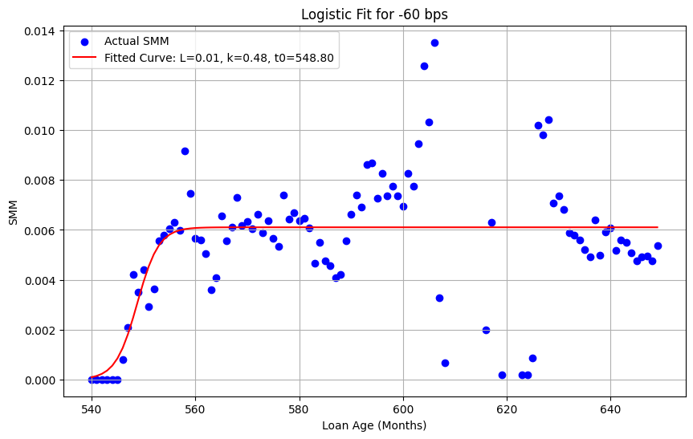

```
Incentive Group: -50 bps
回归参数: L=0.0069, k=0.6741, t0=549.0322
```

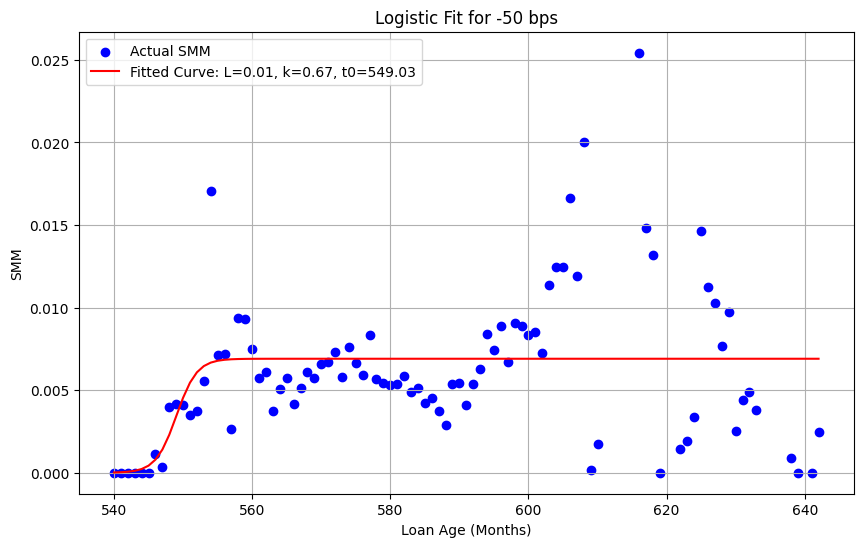

```
Incentive Group: -40 bps
回归参数: L=0.0094, k=0.0633, t0=561.8221
```

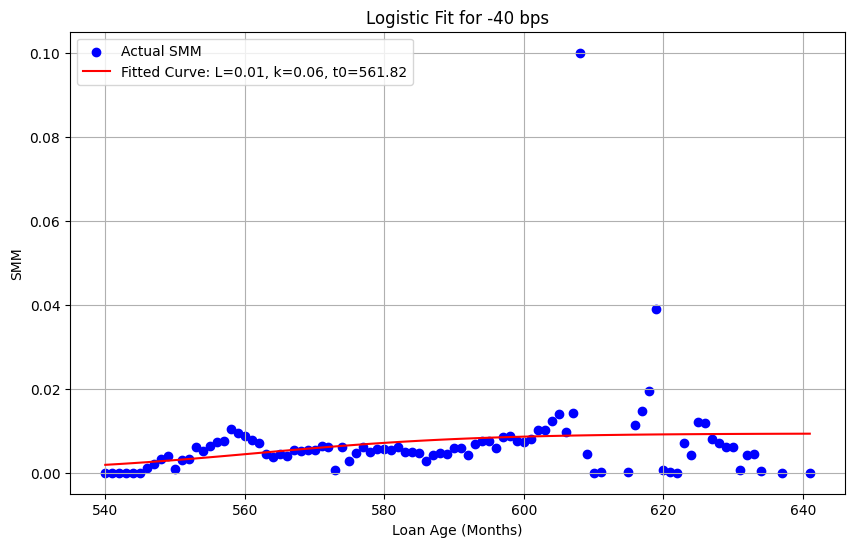

```
Incentive Group: -30 bps
回归参数: L=0.0088, k=0.0639, t0=561.6358
```

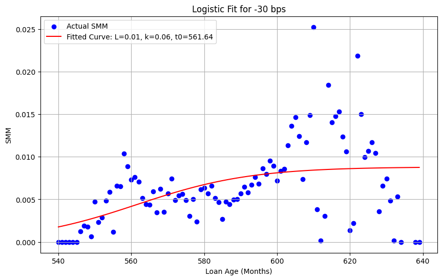

```
Incentive Group: -20 bps
回归参数: L=0.0099, k=0.0548, t0=566.4857
```

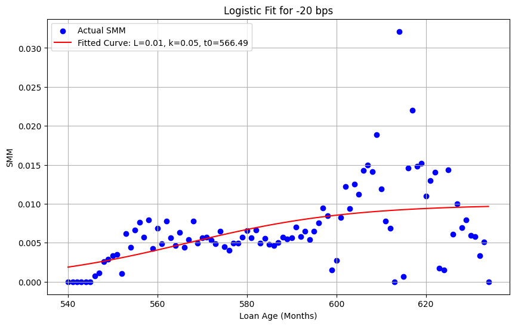

```
Incentive Group: -10 bps
回归参数: L=0.0121, k=0.0541, t0=573.5848
```

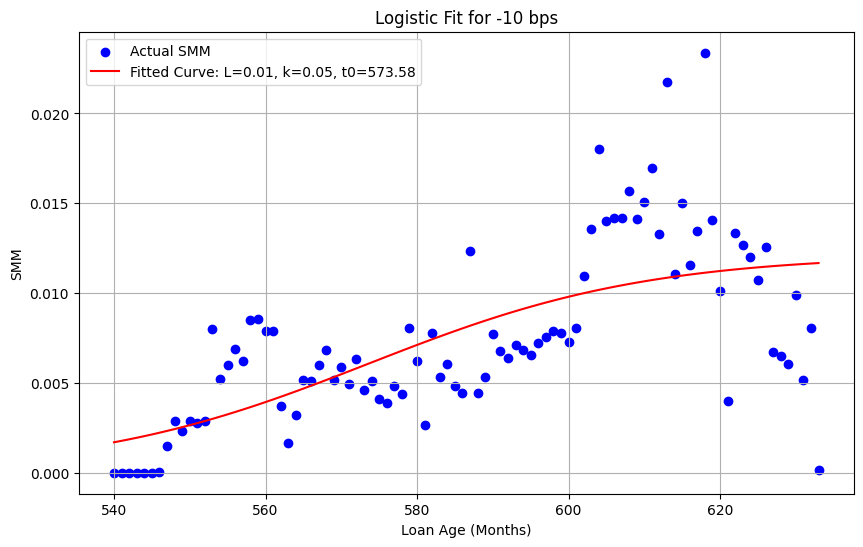

```
Incentive Group: base bps
回归参数: L=0.0189, k=0.0328, t0=601.4487
```

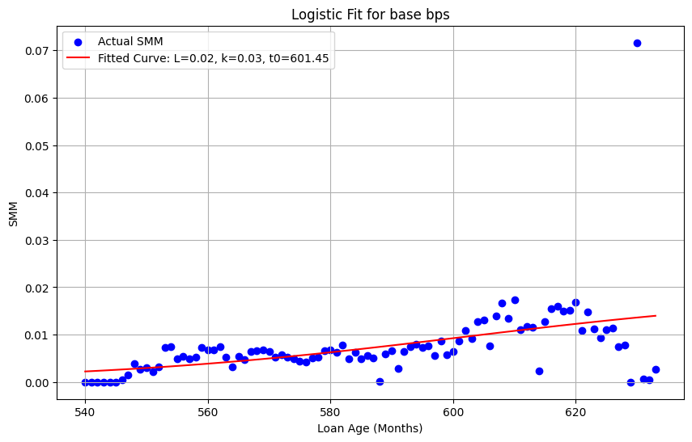

```python
Q1_2015_S_curve['Origination Date'] = Q1_2015['Origination Date']
param_list = lock_in_effect(Q1_2015_S_curve)
```

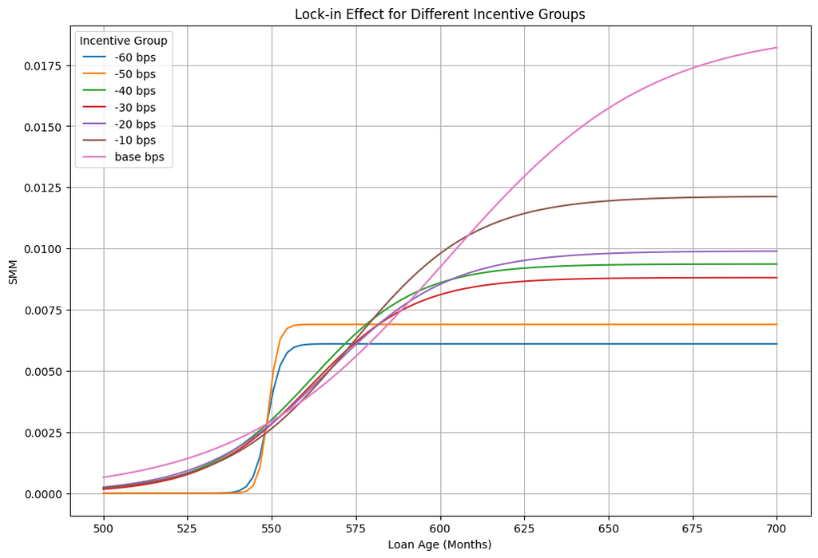

```python
plot_all_curves(param_list)
```

# Curtailment

❑ Partial Prepayments, also known as Curtailments, are extra payments of principal beyond scheduled principal.  
❑ Monthly payment due on a level payment mortgage is fixed, when a borrower sends in a larger monthly payment than  
the one due, the borrower is effectively shortening the remaining term of the mortgage.  
❑ For simplicity, we will use the following function to by loan age ‘t’

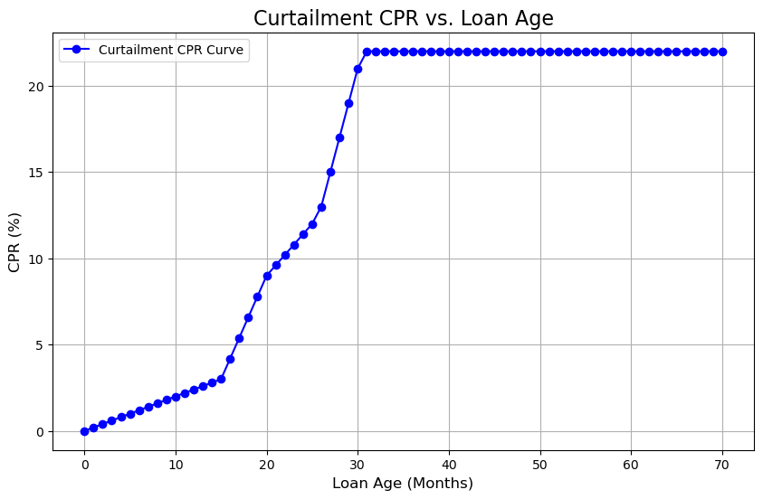

```python
def Curtailment_CPR(t):
    if 0 <= t <= 15:
        return (1/5) * t
    elif 15 < t <= 20:
        return (6/5) * (t - 15) + 3
    elif 20 < t <= 25:
        return (3/5) * (t - 20) + 9
    elif 25 < t <= 30:
        return 2 * (t - 15) - 9
    elif 30 < t <= 70:
        return 22
    else:
        return "t is out of range"

t_values = np.arange(0, 71, 1)
cpr_values = [Curtailment_CPR(t) for t in t_values]

plt.figure(figsize=(10, 6))
plt.plot(t_values, cpr_values, label='Curtailment CPR Curve', color='b', marker='o')

plt.title('Curtailment CPR vs. Loan Age', fontsize=16)
plt.xlabel('Loan Age (Months)', fontsize=12)
plt.ylabel('CPR (%)', fontsize=12)
plt.grid(True)
plt.legend()


plt.show()
```

## Convert to HTML

```python
from nbconvert import HTMLExporter
import nbformat

# 读取 Notebook 文件，指定编码为 'utf-8'
with open('Final_Project_DCJ.ipynb', encoding='utf-8') as f:
    notebook_content = nbformat.read(f, as_version=4)

# 创建 HTML 导出器并转换
html_exporter = HTMLExporter()
(body, resources) = html_exporter.from_notebook_node(notebook_content)

# 保存为 HTML 文件
with open('Prepayment_Code_and_Summary.html', 'w', encoding='utf-8') as f:
    f.write(body)
```